# Image Colorization

## CSCI E-89: Deep Learning Final Project

## Jeffery Downing

```python
import os, shutil
import cv2
import numpy as np
import matplotlib.pyplot as plt
import glob

import tensorflow as tf
from tensorflow import keras
from tensorflow.keras import layers, models, Input, optimizers, Model
from keras.models import load_model
from keras.applications import VGG16
```

## Define directories

- A sample of 80 training images for dogs and landscapes have been provided.
- Please follow the steps in `Image_Colorization_Data_Setup.ipynb` to use the 1000 training images used in this project.

```python
# The directory for dog images subset
dogs_base_dir = 'dog_images'

# Directories for our training, validation and test splits
dogs_train_dir = os.path.join(dogs_base_dir, 'train')
dogs_validation_dir = os.path.join(dogs_base_dir, 'validation')
dogs_test_dir = os.path.join(dogs_base_dir, 'test')
```

```python
# The directory for landscapes images subset
landscape_base_dir = 'landscape_images'

# Directories for our training, validation and test splits
landscape_train_dir = os.path.join(landscape_base_dir, 'train')
landscape_validation_dir = os.path.join(landscape_base_dir, 'validation')
landscape_test_dir = os.path.join(landscape_base_dir, 'test')
```

# Model 1: RGB model for Dogs

- I started with colorizing dogs from the dogs_vs_cats dataset.
- 1000 images are used for training, and 500 for validation.
- A sparse autoencoder was used to colorize the image
- A grayscale image is used as the input and the model will return 3 RGB color channels
- Each layer of the encoder uses 3x3 convolutions and reduce the image with a MaxPooling layer
- The decoder was implemented similarly, but used UpSampling2D to return the image to its original size

```python
model_1 = models.Sequential()

# Input is 256 x 256 sized images
# Encoder: Nodes are 32 -> 64 -> 128 with Conv2D in between each to reduce the image size.
model_1.add(layers.Input(shape=(256, 256, 1)))
model_1.add(layers.Conv2D(32, (3, 3), activation='relu', padding='same'))
model_1.add(layers.MaxPooling2D((2, 2)))
model_1.add(layers.Conv2D(64, (3, 3), activation='relu', padding='same'))
model_1.add(layers.MaxPooling2D((2, 2)))
model_1.add(layers.Conv2D(128, (3, 3), activation='relu', padding='same'))
model_1.add(layers.MaxPooling2D((2, 2)))

# Bottleneck: 256 nodes on 32 x 32 size images
model_1.add(layers.Conv2D(256, (3, 3), activation='relu', padding='same'))

# Decoder: Nodes are 128 -> 64 -> 32 with UpSampling2D layers to return the image to the original size
model_1.add(layers.UpSampling2D((2, 2)))
model_1.add(layers.Conv2D(128, (3, 3), activation='relu', padding='same'))
model_1.add(layers.UpSampling2D((2, 2)))
model_1.add(layers.Conv2D(64, (3, 3), activation='relu', padding='same'))
model_1.add(layers.UpSampling2D((2, 2)))
model_1.add(layers.Conv2D(32, (3, 3), activation='relu', padding='same'))

# Output: 3 nodes for 3 color channels
model_1.add(layers.Conv2D(3, (3, 3), activation='sigmoid', padding='same'))

model_1.summary()
```

```
Model: "sequential_1"
```

```
┏━━━━━━━━━━━━━━━━━━━━━━━━━━━━━━━━━┳━━━━━━━━━━━━━━━━━━━━━━━━┳━━━━━━━━━━━━━━━┓
┃ Layer (type)                    ┃ Output Shape           ┃       Param # ┃
┡━━━━━━━━━━━━━━━━━━━━━━━━━━━━━━━━━╇━━━━━━━━━━━━━━━━━━━━━━━━╇━━━━━━━━━━━━━━━┩
│ conv2d_8 (Conv2D)               │ (None, 256, 256, 32)   │           320 │
├─────────────────────────────────┼────────────────────────┼───────────────┤
│ max_pooling2d_3 (MaxPooling2D)  │ (None, 128, 128, 32)   │             0 │
├─────────────────────────────────┼────────────────────────┼───────────────┤
│ conv2d_9 (Conv2D)               │ (None, 128, 128, 64)   │        18,496 │
├─────────────────────────────────┼────────────────────────┼───────────────┤
│ max_pooling2d_4 (MaxPooling2D)  │ (None, 64, 64, 64)     │             0 │
├─────────────────────────────────┼────────────────────────┼───────────────┤
│ conv2d_10 (Conv2D)              │ (None, 64, 64, 128)    │        73,856 │
├─────────────────────────────────┼────────────────────────┼───────────────┤
│ max_pooling2d_5 (MaxPooling2D)  │ (None, 32, 32, 128)    │             0 │
├─────────────────────────────────┼────────────────────────┼───────────────┤
│ conv2d_11 (Conv2D)              │ (None, 32, 32, 256)    │       295,168 │
├─────────────────────────────────┼────────────────────────┼───────────────┤
│ up_sampling2d_3 (UpSampling2D)  │ (None, 64, 64, 256)    │             0 │
├─────────────────────────────────┼────────────────────────┼───────────────┤
│ conv2d_12 (Conv2D)              │ (None, 64, 64, 128)    │       295,040 │
├─────────────────────────────────┼────────────────────────┼───────────────┤
│ up_sampling2d_4 (UpSampling2D)  │ (None, 128, 128, 128)  │             0 │
├─────────────────────────────────┼────────────────────────┼───────────────┤
│ conv2d_13 (Conv2D)              │ (None, 128, 128, 64)   │        73,792 │
├─────────────────────────────────┼────────────────────────┼───────────────┤
│ up_sampling2d_5 (UpSampling2D)  │ (None, 256, 256, 64)   │             0 │
├─────────────────────────────────┼────────────────────────┼───────────────┤
│ conv2d_14 (Conv2D)              │ (None, 256, 256, 32)   │        18,464 │
├─────────────────────────────────┼────────────────────────┼───────────────┤
│ conv2d_15 (Conv2D)              │ (None, 256, 256, 3)    │           867 │
└─────────────────────────────────┴────────────────────────┴───────────────┘
```

```
 Total params: 776,003 (2.96 MB)
```

```
 Trainable params: 776,003 (2.96 MB)
```

```
 Non-trainable params: 0 (0.00 B)
```

## Create training and validation batches

```python
from tensorflow.keras.preprocessing.image import ImageDataGenerator

# All images will be rescaled by 1./255
train_datagen = ImageDataGenerator(rescale=1./255)
test_datagen = ImageDataGenerator(rescale=1./255)

train_color = train_datagen.flow_from_directory(
        # Get the training directory
        dogs_train_dir,
        # All images will be resized to 256x256
        target_size=(256, 256),
        # keep images in color
        color_mode='rgb',
        batch_size=20,
        # We are interested in image colorization, so there are no classes
        class_mode=None)

train_grayscale = train_datagen.flow_from_directory(
        dogs_train_dir,
        target_size=(256, 256),
        # convert to black and white
        color_mode='grayscale',
        batch_size=20,
        class_mode=None)

validation_color = train_datagen.flow_from_directory(
        # Get the validation directory
        dogs_validation_dir,
        target_size=(256, 256),
        color_mode='rgb',
        batch_size=20,
        class_mode=None)

validation_grayscale = train_datagen.flow_from_directory(
        dogs_validation_dir,
        target_size=(256, 256),
        color_mode='grayscale',
        batch_size=20,
        class_mode=None)
```

```
Found 1000 images belonging to 1 classes.
Found 1000 images belonging to 1 classes.
Found 500 images belonging to 1 classes.
Found 500 images belonging to 1 classes.
```

```python
# Create training and validation generators
def train_generator():
    for gray_batch, color_batch in zip(train_grayscale, train_color):
        yield (gray_batch, color_batch)

def validation_generator():
    for gray_batch, color_batch in zip(validation_grayscale, validation_color):
        yield (gray_batch, color_batch)
```

## Fit the model

```python
model_1.compile(loss='mse',
              optimizer='adam')

history_1 = model_1.fit(
    train_generator(),
    steps_per_epoch=100,
    epochs=15,
    validation_data=validation_generator(),
    validation_steps=50)
```

```
100/100 ━━━━━━━━━━━━━━━━━━━━ 406s 4s/step - loss: 0.0642 - val_loss: 0.0649
100/100 ━━━━━━━━━━━━━━━━━━━━ 21s 214ms/step - loss: 0.0649 - val_loss: 0.0650
100/100 ━━━━━━━━━━━━━━━━━━━━ 21s 214ms/step - loss: 0.0645 - val_loss: 0.0648
100/100 ━━━━━━━━━━━━━━━━━━━━ 21s 213ms/step - loss: 0.0646 - val_loss: 0.0649
100/100 ━━━━━━━━━━━━━━━━━━━━ 22s 216ms/step - loss: 0.0646 - val_loss: 0.0653
100/100 ━━━━━━━━━━━━━━━━━━━━ 21s 215ms/step - loss: 0.0644 - val_loss: 0.0647
100/100 ━━━━━━━━━━━━━━━━━━━━ 22s 217ms/step - loss: 0.0633 - val_loss: 0.0648
100/100 ━━━━━━━━━━━━━━━━━━━━ 22s 216ms/step - loss: 0.0649 - val_loss: 0.0647
100/100 ━━━━━━━━━━━━━━━━━━━━ 22s 216ms/step - loss: 0.0636 - val_loss: 0.0650
100/100 ━━━━━━━━━━━━━━━━━━━━ 22s 216ms/step - loss: 0.0644 - val_loss: 0.0651
100/100 ━━━━━━━━━━━━━━━━━━━━ 22s 216ms/step - loss: 0.0649 - val_loss: 0.0651
100/100 ━━━━━━━━━━━━━━━━━━━━ 22s 216ms/step - loss: 0.0636 - val_loss: 0.0648
100/100 ━━━━━━━━━━━━━━━━━━━━ 22s 217ms/step - loss: 0.0638 - val_loss: 0.0649
100/100 ━━━━━━━━━━━━━━━━━━━━ 21s 214ms/step - loss: 0.0639 - val_loss: 0.0652
100/100 ━━━━━━━━━━━━━━━━━━━━ 22s 216ms/step - loss: 0.0642 - val_loss: 0.0650
```

```python
def print_history(history):
    acc = history.history['loss']
    val_acc = history.history['val_loss']

    epochs = range(1, len(acc) + 1)

    plt.plot(epochs, acc, 'bo', label='Training MSE')
    plt.plot(epochs, val_acc, 'b', label='Validation MSE')
    plt.title('Training and Validation Accuracy')
    plt.xlabel('Epochs')
    plt.ylabel('Accuracy')
    plt.legend()

    plt.show()
```

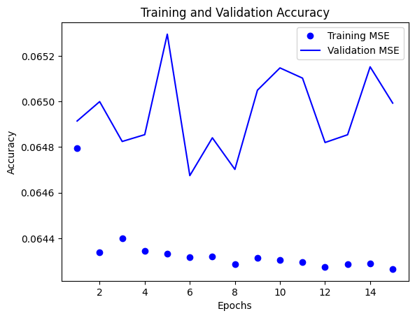

```python
model_1.save_weights('model_1.weights.h5')
print_history(history_1)
```

## Inspecting the model

- Unfortunately, the model was unable to reconstruct the image and only produced a brown box
- It's clear that too much is being asked of the model. It has to reconstruct the entire image and add color, which was too difficult of a task.

```python
model_1.load_weights('model_1.weights.h5')
```

```python
def print_prediction_model_1(model, img_path):
    img = cv2.imread(img_path)

    # Get color image and convert to RGB
    img = cv2.cvtColor(img, cv2.COLOR_BGR2RGB)
    img_resized = cv2.resize(img, (256, 256))
    img_tensor = np.expand_dims(img_resized, axis=0)
    img_tensor = img_tensor / 255.0

    # Get grayscale image
    img_grayscale = cv2.cvtColor(img_resized, cv2.COLOR_RGB2GRAY)
    img_grayscale = np.expand_dims(img_grayscale, axis=-1)
    img_grayscale = np.expand_dims(img_grayscale, axis=0)
    img_grayscale = img_grayscale / 255.0

    # Get prediction image
    img_prediction = model.predict(img_grayscale)
    img_colorized = img_prediction[0]
    img_colorized = np.clip(img_colorized, 0, 1)
    img_colorized = (img_colorized * 255).astype('uint8')

    plt.figure(figsize=(14, 14))
    plt.subplot(1, 3, 1)
    plt.title("Original Image")
    plt.imshow(img_tensor[0])
    plt.axis('off')

    plt.subplot(1, 3, 2)
    plt.title("Grayscale Input")
    plt.imshow(img_grayscale[0], cmap='gray')
    plt.axis('off')

    plt.subplot(1, 3, 3)
    plt.title("Model Output")
    plt.imshow(img_colorized)
    plt.axis('off')
```

```
1/1 ━━━━━━━━━━━━━━━━━━━━ 0s 286ms/step
```

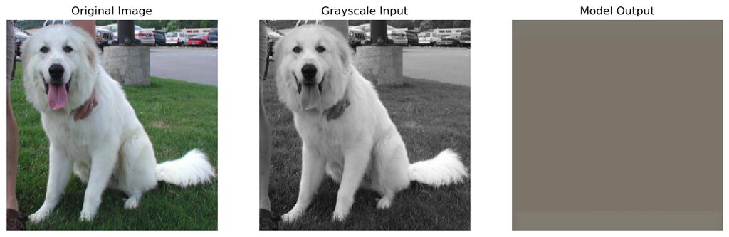

```python
print_prediction_model_1(model_1, 'dog_images/test/dogs/dog.1504.jpg')
```

# Model 2: LAB model for Dogs

- Instead of reproducing three color channels, I explored if there was a simpler approach.
- I learned of the LAB color format, which uses a light channel (L) and two color channels (AB) to construct images.
  - https://www.numberanalytics.com/blog/ultimate-lab-color-guide
- This way the model can focus on coloring and not have to reconstruct the image.
- The structure of this model is the same as the previous, except it outputs two color channels.

```python
model_2 = models.Sequential()

# Input is 256 x 256 sized images
# Encoder: Nodes are 32 -> 64 -> 128 with Conv2D in between each to reduce the image size.
model_2.add(layers.Input(shape=(256, 256, 1)))
model_2.add(layers.Conv2D(32, (3, 3), activation='relu', padding='same'))
model_2.add(layers.MaxPooling2D((2, 2)))
model_2.add(layers.Conv2D(64, (3, 3), activation='relu', padding='same'))
model_2.add(layers.MaxPooling2D((2, 2)))
model_2.add(layers.Conv2D(128, (3, 3), activation='relu', padding='same'))
model_2.add(layers.MaxPooling2D((2, 2)))

# Bottleneck: 256 nodes on 32 x 32 size images
model_2.add(layers.Conv2D(256, (3, 3), activation='relu', padding='same'))

# Decoder: Nodes are 128 -> 64 -> 32 with UpSampling2D layers to return the image to the original size
model_2.add(layers.UpSampling2D((2, 2)))
model_2.add(layers.Conv2D(128, (3, 3), activation='relu', padding='same'))
model_2.add(layers.UpSampling2D((2, 2)))
model_2.add(layers.Conv2D(64, (3, 3), activation='relu', padding='same'))
model_2.add(layers.UpSampling2D((2, 2)))
model_2.add(layers.Conv2D(32, (3, 3), activation='relu', padding='same'))

# Output: There are now two nodes for the AB channels
model_2.add(layers.Conv2D(2, (3, 3), activation='sigmoid', padding='same'))

model_2.summary()
```

```
Model: "sequential_2"
```

```
┏━━━━━━━━━━━━━━━━━━━━━━━━━━━━━━━━━┳━━━━━━━━━━━━━━━━━━━━━━━━┳━━━━━━━━━━━━━━━┓
┃ Layer (type)                    ┃ Output Shape           ┃       Param # ┃
┡━━━━━━━━━━━━━━━━━━━━━━━━━━━━━━━━━╇━━━━━━━━━━━━━━━━━━━━━━━━╇━━━━━━━━━━━━━━━┩
│ conv2d_16 (Conv2D)              │ (None, 256, 256, 32)   │           320 │
├─────────────────────────────────┼────────────────────────┼───────────────┤
│ max_pooling2d_6 (MaxPooling2D)  │ (None, 128, 128, 32)   │             0 │
├─────────────────────────────────┼────────────────────────┼───────────────┤
│ conv2d_17 (Conv2D)              │ (None, 128, 128, 64)   │        18,496 │
├─────────────────────────────────┼────────────────────────┼───────────────┤
│ max_pooling2d_7 (MaxPooling2D)  │ (None, 64, 64, 64)     │             0 │
├─────────────────────────────────┼────────────────────────┼───────────────┤
│ conv2d_18 (Conv2D)              │ (None, 64, 64, 128)    │        73,856 │
├─────────────────────────────────┼────────────────────────┼───────────────┤
│ max_pooling2d_8 (MaxPooling2D)  │ (None, 32, 32, 128)    │             0 │
├─────────────────────────────────┼────────────────────────┼───────────────┤
│ conv2d_19 (Conv2D)              │ (None, 32, 32, 256)    │       295,168 │
├─────────────────────────────────┼────────────────────────┼───────────────┤
│ up_sampling2d_6 (UpSampling2D)  │ (None, 64, 64, 256)    │             0 │
├─────────────────────────────────┼────────────────────────┼───────────────┤
│ conv2d_20 (Conv2D)              │ (None, 64, 64, 128)    │       295,040 │
├─────────────────────────────────┼────────────────────────┼───────────────┤
│ up_sampling2d_7 (UpSampling2D)  │ (None, 128, 128, 128)  │             0 │
├─────────────────────────────────┼────────────────────────┼───────────────┤
│ conv2d_21 (Conv2D)              │ (None, 128, 128, 64)   │        73,792 │
├─────────────────────────────────┼────────────────────────┼───────────────┤
│ up_sampling2d_8 (UpSampling2D)  │ (None, 256, 256, 64)   │             0 │
├─────────────────────────────────┼────────────────────────┼───────────────┤
│ conv2d_22 (Conv2D)              │ (None, 256, 256, 32)   │        18,464 │
├─────────────────────────────────┼────────────────────────┼───────────────┤
│ conv2d_23 (Conv2D)              │ (None, 256, 256, 2)    │           578 │
└─────────────────────────────────┴────────────────────────┴───────────────┘
```

```
 Total params: 775,714 (2.96 MB)
```

```
 Trainable params: 775,714 (2.96 MB)
```

```
 Non-trainable params: 0 (0.00 B)
```

## Create training and validation batches

- The following code takes the training and validation images, resizes them to 256 x 256, and converts it to LAB.

```python
# helper function to get LAB batches
def my_generator(path, batch_size=20):
    image_paths = glob.glob(path + "/**/*.jpg", recursive=True)
    i=0
    while True:
        batch_paths = image_paths[i:i+batch_size]
        light_list = []
        ab_list = []

        for image_path in batch_paths:
            image = cv2.imread(image_path)
            image = cv2.cvtColor(image, cv2.COLOR_BGR2LAB)
            image = cv2.resize(image, (256, 256))
            image = image.astype("float32") / 255.0

            light  = image[:, :, 0:1]
            ab_channel = image[:, :, 1:3]

            light_list.append(light)
            ab_list.append(ab_channel)

        batch_light = np.stack(light_list, axis=0)
        batch_ab = np.stack(ab_list, axis=0)

        i += batch_size
        if i >= len(image_paths):
            i = 0

        yield batch_light, batch_ab
```

```python
train_path = "dog_images/train"
validation_path = "dog_images/validation"

# Create training and validation generators
train_generator = my_generator(train_path, batch_size=20)
validation_generator = my_generator(validation_path, batch_size=20)
```

## Fit the model

```python
model_2.compile(loss='mse',
              optimizer='adam')

history_2 = model_2.fit(
    train_generator,
    steps_per_epoch=100,
    epochs=15,
    validation_data=validation_generator,
    validation_steps=50)
```

```
100/100 ━━━━━━━━━━━━━━━━━━━━ 28s 220ms/step - loss: 0.0024 - val_loss: 0.0022
100/100 ━━━━━━━━━━━━━━━━━━━━ 20s 206ms/step - loss: 0.0022 - val_loss: 0.0022
100/100 ━━━━━━━━━━━━━━━━━━━━ 21s 209ms/step - loss: 0.0022 - val_loss: 0.0022
100/100 ━━━━━━━━━━━━━━━━━━━━ 20s 203ms/step - loss: 0.0022 - val_loss: 0.0022
100/100 ━━━━━━━━━━━━━━━━━━━━ 21s 210ms/step - loss: 0.0022 - val_loss: 0.0022
100/100 ━━━━━━━━━━━━━━━━━━━━ 21s 210ms/step - loss: 0.0022 - val_loss: 0.0022
100/100 ━━━━━━━━━━━━━━━━━━━━ 21s 206ms/step - loss: 0.0022 - val_loss: 0.0021
100/100 ━━━━━━━━━━━━━━━━━━━━ 21s 207ms/step - loss: 0.0022 - val_loss: 0.0021
100/100 ━━━━━━━━━━━━━━━━━━━━ 21s 209ms/step - loss: 0.0022 - val_loss: 0.0021
100/100 ━━━━━━━━━━━━━━━━━━━━ 21s 208ms/step - loss: 0.0022 - val_loss: 0.0021
100/100 ━━━━━━━━━━━━━━━━━━━━ 21s 207ms/step - loss: 0.0022 - val_loss: 0.0021
100/100 ━━━━━━━━━━━━━━━━━━━━ 21s 208ms/step - loss: 0.0022 - val_loss: 0.0021
100/100 ━━━━━━━━━━━━━━━━━━━━ 21s 209ms/step - loss: 0.0021 - val_loss: 0.0021
100/100 ━━━━━━━━━━━━━━━━━━━━ 21s 207ms/step - loss: 0.0021 - val_loss: 0.0021
100/100 ━━━━━━━━━━━━━━━━━━━━ 21s 209ms/step - loss: 0.0021 - val_loss: 0.0020
```

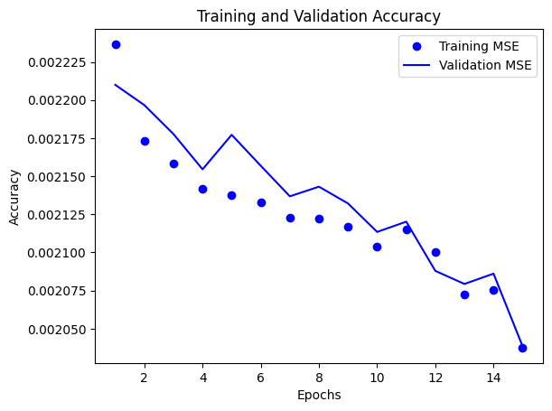

```python
model_2.save_weights('model_2.weights.h5')
print_history(history_2)
```

## Inspecting the model

- The model performed much better and produced decent results.
- A reasonable color was given to the dog, and the background was painted green, regardless of what was there.
- The model appears to have learned that many backgrounds have green grass in them.
  - One image containing concrete in the background was painted entirely green.
- As expected, the model had difficulty painting in background details. For example, it painted a parking lot red-grey.
- It is clear that our models are heavily influenced by their training dataset.

```python
def get_color_image(model, img_grayscale, img_prediction, strength):
    # Create lab array
    lab = np.full((256, 256, 3), 128, dtype="uint8")

    # Get AB channels.  Strength will push the values away from 0.5
    ab = ((((img_prediction[0] - 0.5) * strength) + 0.5) * 255).astype("uint8")
    lab[:, :, 1:3] = ab

    # If a grayscale image was provided, apply it to the Light channel
    if img_grayscale is not None:
        Light  = (img_grayscale[0]  * 255).astype("uint8")
        lab[:, :, 0:1] = Light

    img_colorized = cv2.cvtColor(lab, cv2.COLOR_LAB2RGB)
    return img_colorized
```

```python
def print_prediction(model, img_path, strength = 1):
    img = cv2.imread(img_path)

    # Get color image
    img = cv2.cvtColor(img, cv2.COLOR_BGR2RGB) # Fix coloring
    img_resized = cv2.resize(img, (256, 256)) # Trim to 256 x 256
    img_tensor = np.expand_dims(img_resized, axis=0)
    img_tensor = img_tensor / 255.0

    # Get grayscale image
    img_grayscale = cv2.cvtColor(img_resized, cv2.COLOR_RGB2GRAY)
    img_grayscale = np.expand_dims(img_grayscale, axis=-1)
    img_grayscale = np.expand_dims(img_grayscale, axis=0)
    img_grayscale = img_grayscale / 255.0

    # Get prediction image
    img_prediction = model.predict(img_grayscale)
    img_colorized = get_color_image(model, img_grayscale, img_prediction, strength)
    img_colors_only = get_color_image(model, None, img_prediction, strength)

    plt.figure(figsize=(8, 8))

    names = ["Original Image", "Grayscale Input", "Model Output", "Colors Only"]
    images = [img_tensor[0], img_grayscale[0], img_colorized, img_colors_only]
    i = 1
    for name, image in zip(names, images):
        plt.subplot(1, 4, i)
        plt.title(name)
        if i == 2:
            plt.imshow(image, cmap='gray')
        else:
            plt.imshow(image)
        plt.axis('off')
        i += 1
    plt.show()
```

```
1/1 ━━━━━━━━━━━━━━━━━━━━ 0s 441ms/step
```

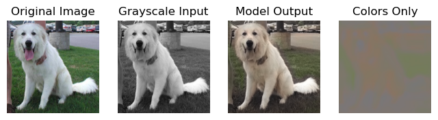

```
1/1 ━━━━━━━━━━━━━━━━━━━━ 0s 70ms/step
```

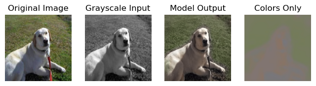

```
1/1 ━━━━━━━━━━━━━━━━━━━━ 0s 67ms/step
```

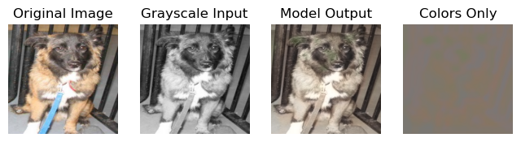

```
1/1 ━━━━━━━━━━━━━━━━━━━━ 0s 61ms/step
```

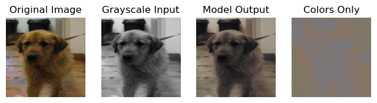

```
1/1 ━━━━━━━━━━━━━━━━━━━━ 0s 61ms/step
```

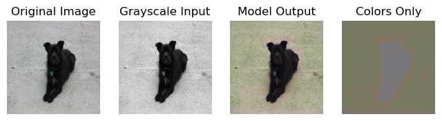

```python
print_prediction(model_2, 'dog_images/test/dogs/dog.1504.jpg')
print_prediction(model_2, 'dog_images/test/dogs/dog.1505.jpg')
print_prediction(model_2, 'dog_images/test/dogs/dog.1605.jpg')
print_prediction(model_2, 'dog_images/test/dogs/dog.1613.jpg')
print_prediction(model_2, 'dog_images/test/dogs/dog.1602.jpg')
```

# Model 3: Complex LAB model for Dogs

```python
def complex_lab_model(input_size = 256):
    input_layer = Input(shape=(input_size, input_size, 1))

    # Encoder: In each block, run Conv2D twice with BatchNormalization.
    #          Then apply MaxPooling
    #          Save a copy of the output at each block to use in the respective block of the decoder

    # Block 1: 64 Nodes in each layer.  Inputs are 256 x 256
    x = layers.Conv2D(64, (3, 3), padding='same', activation='relu')(input_layer)
    x = layers.BatchNormalization()(x)
    x = layers.Conv2D(64, (3, 3), padding='same', activation='relu')(x)
    x = layers.BatchNormalization()(x)
    x = layers.MaxPooling2D((2, 2))(x)
    enc1 = x

    # Block 2: 128 Nodes in each layer.  Inputs are 128 x 128.
    x = layers.Conv2D(128, (3, 3), padding='same', activation='relu')(x)
    x = layers.BatchNormalization()(x)
    x = layers.Conv2D(128, (3, 3), padding='same', activation='relu')(x)
    x = layers.BatchNormalization()(x)
    x = layers.MaxPooling2D((2, 2))(x)
    enc2 = x

    # Block 3: 256 Nodes in each layer.  Inputs are 64 x 64.
    x = layers.Conv2D(256, (3, 3), padding='same', activation='relu')(x)
    x = layers.BatchNormalization()(x)
    x = layers.Conv2D(256, (3, 3), padding='same', activation='relu')(x)
    x = layers.BatchNormalization()(x)
    x = layers.MaxPooling2D((2, 2))(x)
    enc3 = x

    # Bottleneck: Two ConV2D layers with 512 nodes
    x = layers.Conv2D(512, (3, 3), padding='same', activation='relu')(x)
    x = layers.BatchNormalization()(x)
    x = layers.Conv2D(512, (3, 3), padding='same', activation='relu')(x)
    x = layers.BatchNormalization()(x)

    # Decoder: In each block, run UpSampling2D then run Conv2D twice with BatchNormalization.
    #          Then concatenate with the layer from the encoding block

    # Block 1: 256 Nodes in each layer.  Outputs are 64 x 64.
    x = layers.Concatenate()([x, enc3])
    x = layers.UpSampling2D((2, 2))(x)
    x = layers.Conv2D(256, (3, 3), padding='same', activation='relu')(x)
    x = layers.BatchNormalization()(x)
    x = layers.Conv2D(256, (3, 3), padding='same', activation='relu')(x)
    x = layers.BatchNormalization()(x)

    # Block 2: 128 Nodes in each layer.  Outputs are 128 x 128.
    x = layers.Concatenate()([x, enc2])
    x = layers.UpSampling2D((2, 2))(x)
    x = layers.Conv2D(128, (3, 3), padding='same', activation='relu')(x)
    x = layers.BatchNormalization()(x)
    x = layers.Conv2D(128, (3, 3), padding='same', activation='relu')(x)
    x = layers.BatchNormalization()(x)

    # Block 3: 64 Nodes in each layer.  Outputs are 256 x 256.
    x = layers.Concatenate()([x, enc1])
    x = layers.UpSampling2D((2, 2))(x)
    x = layers.Conv2D(64, (3, 3), padding='same', activation='relu')(x)
    x = layers.BatchNormalization()(x)
    x = layers.Conv2D(64, (3, 3), padding='same', activation='relu')(x)
    x = layers.BatchNormalization()(x)

    # Output: AB channels
    output_layer = layers.Conv2D(2, (1, 1), activation='sigmoid', padding='same')(x)

    model = models.Model(input_layer, output_layer)
    return model

model_3 = complex_lab_model()
model_3.summary()
```

```
Model: "functional_43"
```

```
┏━━━━━━━━━━━━━━━━━━━━━┳━━━━━━━━━━━━━━━━━━━┳━━━━━━━━━━━━┳━━━━━━━━━━━━━━━━━━━┓
┃ Layer (type)        ┃ Output Shape      ┃    Param # ┃ Connected to      ┃
┡━━━━━━━━━━━━━━━━━━━━━╇━━━━━━━━━━━━━━━━━━━╇━━━━━━━━━━━━╇━━━━━━━━━━━━━━━━━━━┩
│ input_layer_4       │ (None, 256, 256,  │          0 │ -                 │
│ (InputLayer)        │ 1)                │            │                   │
├─────────────────────┼───────────────────┼────────────┼───────────────────┤
│ conv2d_39 (Conv2D)  │ (None, 256, 256,  │        640 │ input_layer_4[0]… │
│                     │ 64)               │            │                   │
├─────────────────────┼───────────────────┼────────────┼───────────────────┤
│ batch_normalizatio… │ (None, 256, 256,  │        256 │ conv2d_39[0][0]   │
│ (BatchNormalizatio… │ 64)               │            │                   │
├─────────────────────┼───────────────────┼────────────┼───────────────────┤
│ conv2d_40 (Conv2D)  │ (None, 256, 256,  │     36,928 │ batch_normalizat… │
│                     │ 64)               │            │                   │
├─────────────────────┼───────────────────┼────────────┼───────────────────┤
│ batch_normalizatio… │ (None, 256, 256,  │        256 │ conv2d_40[0][0]   │
│ (BatchNormalizatio… │ 64)               │            │                   │
├─────────────────────┼───────────────────┼────────────┼───────────────────┤
│ max_pooling2d_12    │ (None, 128, 128,  │          0 │ batch_normalizat… │
│ (MaxPooling2D)      │ 64)               │            │                   │
├─────────────────────┼───────────────────┼────────────┼───────────────────┤
│ conv2d_41 (Conv2D)  │ (None, 128, 128,  │     73,856 │ max_pooling2d_12… │
│                     │ 128)              │            │                   │
├─────────────────────┼───────────────────┼────────────┼───────────────────┤
│ batch_normalizatio… │ (None, 128, 128,  │        512 │ conv2d_41[0][0]   │
│ (BatchNormalizatio… │ 128)              │            │                   │
├─────────────────────┼───────────────────┼────────────┼───────────────────┤
│ conv2d_42 (Conv2D)  │ (None, 128, 128,  │    147,584 │ batch_normalizat… │
│                     │ 128)              │            │                   │
├─────────────────────┼───────────────────┼────────────┼───────────────────┤
│ batch_normalizatio… │ (None, 128, 128,  │        512 │ conv2d_42[0][0]   │
│ (BatchNormalizatio… │ 128)              │            │                   │
├─────────────────────┼───────────────────┼────────────┼───────────────────┤
│ max_pooling2d_13    │ (None, 64, 64,    │          0 │ batch_normalizat… │
│ (MaxPooling2D)      │ 128)              │            │                   │
├─────────────────────┼───────────────────┼────────────┼───────────────────┤
│ conv2d_43 (Conv2D)  │ (None, 64, 64,    │    295,168 │ max_pooling2d_13… │
│                     │ 256)              │            │                   │
├─────────────────────┼───────────────────┼────────────┼───────────────────┤
│ batch_normalizatio… │ (None, 64, 64,    │      1,024 │ conv2d_43[0][0]   │
```

[output cut: 65 more lines]

```
│ conv2d_51 (Conv2D)  │ (None, 256, 256,  │    110,656 │ up_sampling2d_14… │
│                     │ 64)               │            │                   │
├─────────────────────┼───────────────────┼────────────┼───────────────────┤
│ batch_normalizatio… │ (None, 256, 256,  │        256 │ conv2d_51[0][0]   │
│ (BatchNormalizatio… │ 64)               │            │                   │
├─────────────────────┼───────────────────┼────────────┼───────────────────┤
│ conv2d_52 (Conv2D)  │ (None, 256, 256,  │     36,928 │ batch_normalizat… │
│                     │ 64)               │            │                   │
├─────────────────────┼───────────────────┼────────────┼───────────────────┤
│ batch_normalizatio… │ (None, 256, 256,  │        256 │ conv2d_52[0][0]   │
│ (BatchNormalizatio… │ 64)               │            │                   │
├─────────────────────┼───────────────────┼────────────┼───────────────────┤
│ conv2d_53 (Conv2D)  │ (None, 256, 256,  │        130 │ batch_normalizat… │
│                     │ 2)                │            │                   │
└─────────────────────┴───────────────────┴────────────┴───────────────────┘
```

```
 Total params: 7,793,090 (29.73 MB)
```

```
 Trainable params: 7,787,458 (29.71 MB)
```

```
 Non-trainable params: 5,632 (22.00 KB)
```

```python
# Create training and validation generators
train_generator = my_generator(train_path, batch_size=20)
validation_generator = my_generator(validation_path, batch_size=20)
```

## Fit the model

```python
model_3.compile(loss='mse',
              optimizer='adam')

history_3 = model_3.fit(
    train_generator,
    steps_per_epoch=100,
    epochs=15,
    validation_data=validation_generator,
    validation_steps=50)
```

```
100/100 ━━━━━━━━━━━━━━━━━━━━ 207s 1s/step - loss: 0.0121 - val_loss: 0.0031
100/100 ━━━━━━━━━━━━━━━━━━━━ 102s 1s/step - loss: 0.0022 - val_loss: 0.0023
100/100 ━━━━━━━━━━━━━━━━━━━━ 103s 1s/step - loss: 0.0022 - val_loss: 0.0024
100/100 ━━━━━━━━━━━━━━━━━━━━ 103s 1s/step - loss: 0.0021 - val_loss: 0.0024
100/100 ━━━━━━━━━━━━━━━━━━━━ 103s 1s/step - loss: 0.0021 - val_loss: 0.0024
100/100 ━━━━━━━━━━━━━━━━━━━━ 103s 1s/step - loss: 0.0021 - val_loss: 0.0023
100/100 ━━━━━━━━━━━━━━━━━━━━ 103s 1s/step - loss: 0.0021 - val_loss: 0.0022
100/100 ━━━━━━━━━━━━━━━━━━━━ 103s 1s/step - loss: 0.0020 - val_loss: 0.0023
100/100 ━━━━━━━━━━━━━━━━━━━━ 103s 1s/step - loss: 0.0020 - val_loss: 0.0022
100/100 ━━━━━━━━━━━━━━━━━━━━ 103s 1s/step - loss: 0.0020 - val_loss: 0.0021
100/100 ━━━━━━━━━━━━━━━━━━━━ 103s 1s/step - loss: 0.0020 - val_loss: 0.0022
100/100 ━━━━━━━━━━━━━━━━━━━━ 103s 1s/step - loss: 0.0020 - val_loss: 0.0021
100/100 ━━━━━━━━━━━━━━━━━━━━ 103s 1s/step - loss: 0.0020 - val_loss: 0.0022
100/100 ━━━━━━━━━━━━━━━━━━━━ 103s 1s/step - loss: 0.0020 - val_loss: 0.0021
100/100 ━━━━━━━━━━━━━━━━━━━━ 103s 1s/step - loss: 0.0020 - val_loss: 0.0024
```

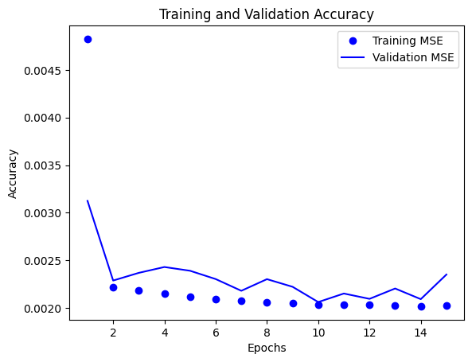

```python
model_3.save_weights('model_3.weights.h5')
print_history(history_3)
```

## Inspecting the model

- Despite the changes, the model performs no better than model 2
- Given this, I chose to abandon this architecture and continue with the simpler autoencoder.

```python
model_3.load_weights('model_3.weights.h5')
```

```
1/1 ━━━━━━━━━━━━━━━━━━━━ 1s 668ms/step
```

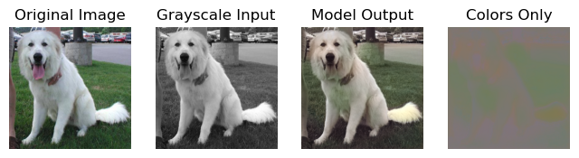

```
1/1 ━━━━━━━━━━━━━━━━━━━━ 0s 210ms/step
```

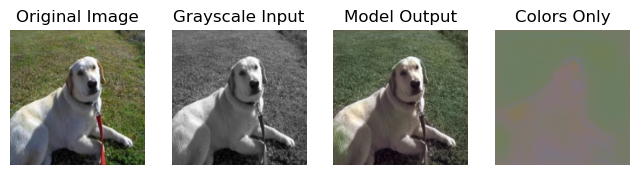

```
1/1 ━━━━━━━━━━━━━━━━━━━━ 0s 189ms/step
```

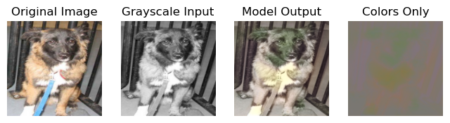

```
1/1 ━━━━━━━━━━━━━━━━━━━━ 0s 195ms/step
```

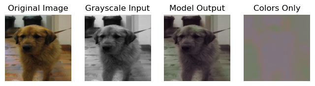

```
1/1 ━━━━━━━━━━━━━━━━━━━━ 0s 231ms/step
```

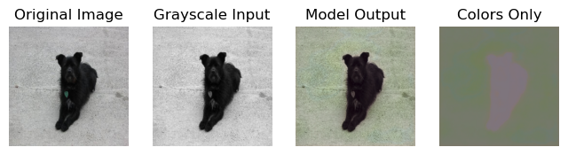

```python
print_prediction(model_3, 'dog_images/test/dogs/dog.1504.jpg')
print_prediction(model_3, 'dog_images/test/dogs/dog.1505.jpg')
print_prediction(model_3, 'dog_images/test/dogs/dog.1605.jpg')
print_prediction(model_3, 'dog_images/test/dogs/dog.1613.jpg')
print_prediction(model_3, 'dog_images/test/dogs/dog.1602.jpg')
```

# Model 4: LAB model for Landscapes

- I wanted to experiment with how a different dataset would influence the model's behavior
- This time, I used images of landscapes with a variety of different enviornments.
  - Including beaches, oceans, forests, and urban buildings
- The goal was to see if the model can identify and reproduce colors from each type of scene.
- The model's architecture is the same as model 2

```python
model_4 = models.Sequential()

# Input is 256 x 256 sized images
# Encoder: Nodes are 32 -> 64 -> 128 with Conv2D in between each to reduce the image size.
model_4.add(layers.Input(shape=(256, 256, 1)))
model_4.add(layers.Conv2D(32, (3, 3), activation='relu', padding='same'))
model_4.add(layers.MaxPooling2D((2, 2)))
model_4.add(layers.Conv2D(64, (3, 3), activation='relu', padding='same'))
model_4.add(layers.MaxPooling2D((2, 2)))
model_4.add(layers.Conv2D(128, (3, 3), activation='relu', padding='same'))
model_4.add(layers.MaxPooling2D((2, 2)))

# Bottleneck: 256 nodes on 32 x 32 size images
model_4.add(layers.Conv2D(256, (3, 3), activation='relu', padding='same'))

# Decoder: Nodes are 128 -> 64 -> 32 with UpSampling2D layers to return the image to the original size
model_4.add(layers.UpSampling2D((2, 2)))
model_4.add(layers.Conv2D(128, (3, 3), activation='relu', padding='same'))
model_4.add(layers.UpSampling2D((2, 2)))
model_4.add(layers.Conv2D(64, (3, 3), activation='relu', padding='same'))
model_4.add(layers.UpSampling2D((2, 2)))
model_4.add(layers.Conv2D(32, (3, 3), activation='relu', padding='same'))

# Output: There are now two nodes for the AB channels
model_4.add(layers.Conv2D(2, (3, 3), activation='sigmoid', padding='same'))

model_4.summary()
```

```
Model: "sequential_3"
```

```
┏━━━━━━━━━━━━━━━━━━━━━━━━━━━━━━━━━┳━━━━━━━━━━━━━━━━━━━━━━━━┳━━━━━━━━━━━━━━━┓
┃ Layer (type)                    ┃ Output Shape           ┃       Param # ┃
┡━━━━━━━━━━━━━━━━━━━━━━━━━━━━━━━━━╇━━━━━━━━━━━━━━━━━━━━━━━━╇━━━━━━━━━━━━━━━┩
│ conv2d_54 (Conv2D)              │ (None, 256, 256, 32)   │           320 │
├─────────────────────────────────┼────────────────────────┼───────────────┤
│ max_pooling2d_15 (MaxPooling2D) │ (None, 128, 128, 32)   │             0 │
├─────────────────────────────────┼────────────────────────┼───────────────┤
│ conv2d_55 (Conv2D)              │ (None, 128, 128, 64)   │        18,496 │
├─────────────────────────────────┼────────────────────────┼───────────────┤
│ max_pooling2d_16 (MaxPooling2D) │ (None, 64, 64, 64)     │             0 │
├─────────────────────────────────┼────────────────────────┼───────────────┤
│ conv2d_56 (Conv2D)              │ (None, 64, 64, 128)    │        73,856 │
├─────────────────────────────────┼────────────────────────┼───────────────┤
│ max_pooling2d_17 (MaxPooling2D) │ (None, 32, 32, 128)    │             0 │
├─────────────────────────────────┼────────────────────────┼───────────────┤
│ conv2d_57 (Conv2D)              │ (None, 32, 32, 256)    │       295,168 │
├─────────────────────────────────┼────────────────────────┼───────────────┤
│ up_sampling2d_15 (UpSampling2D) │ (None, 64, 64, 256)    │             0 │
├─────────────────────────────────┼────────────────────────┼───────────────┤
│ conv2d_58 (Conv2D)              │ (None, 64, 64, 128)    │       295,040 │
├─────────────────────────────────┼────────────────────────┼───────────────┤
│ up_sampling2d_16 (UpSampling2D) │ (None, 128, 128, 128)  │             0 │
├─────────────────────────────────┼────────────────────────┼───────────────┤
│ conv2d_59 (Conv2D)              │ (None, 128, 128, 64)   │        73,792 │
├─────────────────────────────────┼────────────────────────┼───────────────┤
│ up_sampling2d_17 (UpSampling2D) │ (None, 256, 256, 64)   │             0 │
├─────────────────────────────────┼────────────────────────┼───────────────┤
│ conv2d_60 (Conv2D)              │ (None, 256, 256, 32)   │        18,464 │
├─────────────────────────────────┼────────────────────────┼───────────────┤
│ conv2d_61 (Conv2D)              │ (None, 256, 256, 2)    │           578 │
└─────────────────────────────────┴────────────────────────┴───────────────┘
```

```
 Total params: 775,714 (2.96 MB)
```

```
 Trainable params: 775,714 (2.96 MB)
```

```
 Non-trainable params: 0 (0.00 B)
```

```python
train_path = "landscape_images/train"
validation_path = "landscape_images/validation"

# Create training and validation generators
train_generator = my_generator(train_path, batch_size=20)
validation_generator = my_generator(validation_path, batch_size=20)
```

## Fit the model

```python
model_4.compile(loss='mse',
              optimizer='adam')

history_4 = model_4.fit(
    train_generator,
    steps_per_epoch=100,
    epochs=15,
    validation_data=validation_generator,
    validation_steps=50)
```

```
100/100 ━━━━━━━━━━━━━━━━━━━━ 37s 329ms/step - loss: 0.0029 - val_loss: 0.0025
100/100 ━━━━━━━━━━━━━━━━━━━━ 21s 207ms/step - loss: 0.0026 - val_loss: 0.0024
100/100 ━━━━━━━━━━━━━━━━━━━━ 20s 205ms/step - loss: 0.0025 - val_loss: 0.0023
100/100 ━━━━━━━━━━━━━━━━━━━━ 20s 203ms/step - loss: 0.0024 - val_loss: 0.0024
100/100 ━━━━━━━━━━━━━━━━━━━━ 20s 202ms/step - loss: 0.0024 - val_loss: 0.0022
100/100 ━━━━━━━━━━━━━━━━━━━━ 20s 202ms/step - loss: 0.0024 - val_loss: 0.0022
100/100 ━━━━━━━━━━━━━━━━━━━━ 20s 202ms/step - loss: 0.0023 - val_loss: 0.0022
100/100 ━━━━━━━━━━━━━━━━━━━━ 20s 201ms/step - loss: 0.0023 - val_loss: 0.0022
100/100 ━━━━━━━━━━━━━━━━━━━━ 20s 201ms/step - loss: 0.0023 - val_loss: 0.0022
100/100 ━━━━━━━━━━━━━━━━━━━━ 20s 199ms/step - loss: 0.0023 - val_loss: 0.0021
100/100 ━━━━━━━━━━━━━━━━━━━━ 20s 201ms/step - loss: 0.0022 - val_loss: 0.0021
100/100 ━━━━━━━━━━━━━━━━━━━━ 20s 200ms/step - loss: 0.0022 - val_loss: 0.0021
100/100 ━━━━━━━━━━━━━━━━━━━━ 20s 199ms/step - loss: 0.0022 - val_loss: 0.0021
100/100 ━━━━━━━━━━━━━━━━━━━━ 20s 201ms/step - loss: 0.0021 - val_loss: 0.0021
100/100 ━━━━━━━━━━━━━━━━━━━━ 20s 200ms/step - loss: 0.0021 - val_loss: 0.0021
```

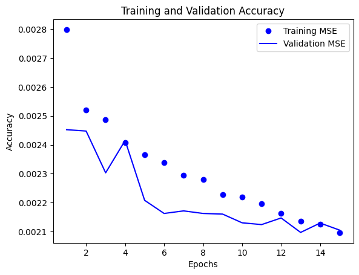

```python
model_4.save_weights('model_4.weights.h5')
print_history(history_4)
```

## Inspecting the model

- Unfortunately, the model had difficulty learning each environment's colors
- The model defaulted to blue and yellow tones

```python
model_4.load_weights('model_4.weights.h5')
```

```
1/1 ━━━━━━━━━━━━━━━━━━━━ 1s 708ms/step
```

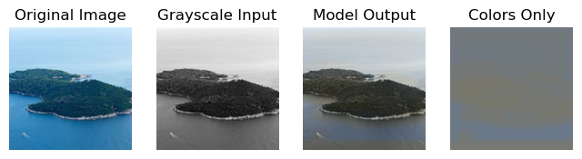

```
1/1 ━━━━━━━━━━━━━━━━━━━━ 0s 71ms/step
```

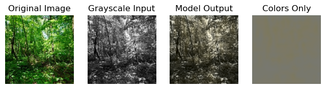

```
1/1 ━━━━━━━━━━━━━━━━━━━━ 0s 66ms/step
```

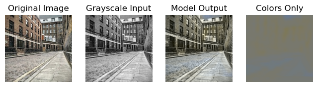

```
1/1 ━━━━━━━━━━━━━━━━━━━━ 0s 63ms/step
```

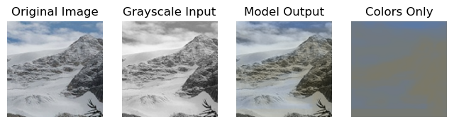

```python
print_prediction(model_4, 'landscape_images/test/landscape/1504.jpg')
print_prediction(model_4, 'landscape_images/test/landscape/1940.jpg')
print_prediction(model_4, 'landscape_images/test/landscape/1503.jpg')
print_prediction(model_4, 'landscape_images/test/landscape/1624.jpg')
```

# Model 5: VGG16 Transfer Learning model for Landscapes

- For my final model, I implemented a transfer learning approach using the VGG16 architecture.
- I would like to use the VGG16 model as my encoder, however the input must have 3 channels.
- I will take the grayscale channel and copy it to all three rgb channels and then run that through the VGG16 model.
- I will be extracting the "block5_conv3" layer of the model with an image size of 16 x 16, and I will input that into the decoder.
- I will also freeze the VGG16 layers.
- The decoder has the same architecture as the previous models

```python
vgg = VGG16(weights="imagenet", include_top=False, input_shape=(256, 256, 3))
vgg.summary()
```

```
Model: "vgg16"
```

```
┏━━━━━━━━━━━━━━━━━━━━━━━━━━━━━━━━━┳━━━━━━━━━━━━━━━━━━━━━━━━┳━━━━━━━━━━━━━━━┓
┃ Layer (type)                    ┃ Output Shape           ┃       Param # ┃
┡━━━━━━━━━━━━━━━━━━━━━━━━━━━━━━━━━╇━━━━━━━━━━━━━━━━━━━━━━━━╇━━━━━━━━━━━━━━━┩
│ input_layer_6 (InputLayer)      │ (None, 256, 256, 3)    │             0 │
├─────────────────────────────────┼────────────────────────┼───────────────┤
│ block1_conv1 (Conv2D)           │ (None, 256, 256, 64)   │         1,792 │
├─────────────────────────────────┼────────────────────────┼───────────────┤
│ block1_conv2 (Conv2D)           │ (None, 256, 256, 64)   │        36,928 │
├─────────────────────────────────┼────────────────────────┼───────────────┤
│ block1_pool (MaxPooling2D)      │ (None, 128, 128, 64)   │             0 │
├─────────────────────────────────┼────────────────────────┼───────────────┤
│ block2_conv1 (Conv2D)           │ (None, 128, 128, 128)  │        73,856 │
├─────────────────────────────────┼────────────────────────┼───────────────┤
│ block2_conv2 (Conv2D)           │ (None, 128, 128, 128)  │       147,584 │
├─────────────────────────────────┼────────────────────────┼───────────────┤
│ block2_pool (MaxPooling2D)      │ (None, 64, 64, 128)    │             0 │
├─────────────────────────────────┼────────────────────────┼───────────────┤
│ block3_conv1 (Conv2D)           │ (None, 64, 64, 256)    │       295,168 │
├─────────────────────────────────┼────────────────────────┼───────────────┤
│ block3_conv2 (Conv2D)           │ (None, 64, 64, 256)    │       590,080 │
├─────────────────────────────────┼────────────────────────┼───────────────┤
│ block3_conv3 (Conv2D)           │ (None, 64, 64, 256)    │       590,080 │
├─────────────────────────────────┼────────────────────────┼───────────────┤
│ block3_pool (MaxPooling2D)      │ (None, 32, 32, 256)    │             0 │
├─────────────────────────────────┼────────────────────────┼───────────────┤
│ block4_conv1 (Conv2D)           │ (None, 32, 32, 512)    │     1,180,160 │
├─────────────────────────────────┼────────────────────────┼───────────────┤
│ block4_conv2 (Conv2D)           │ (None, 32, 32, 512)    │     2,359,808 │
├─────────────────────────────────┼────────────────────────┼───────────────┤
│ block4_conv3 (Conv2D)           │ (None, 32, 32, 512)    │     2,359,808 │
├─────────────────────────────────┼────────────────────────┼───────────────┤
│ block4_pool (MaxPooling2D)      │ (None, 16, 16, 512)    │             0 │
├─────────────────────────────────┼────────────────────────┼───────────────┤
│ block5_conv1 (Conv2D)           │ (None, 16, 16, 512)    │     2,359,808 │
├─────────────────────────────────┼────────────────────────┼───────────────┤
│ block5_conv2 (Conv2D)           │ (None, 16, 16, 512)    │     2,359,808 │
├─────────────────────────────────┼────────────────────────┼───────────────┤
│ block5_conv3 (Conv2D)           │ (None, 16, 16, 512)    │     2,359,808 │
├─────────────────────────────────┼────────────────────────┼───────────────┤
│ block5_pool (MaxPooling2D)      │ (None, 8, 8, 512)      │             0 │
└─────────────────────────────────┴────────────────────────┴───────────────┘
```

```
 Total params: 14,714,688 (56.13 MB)
```

```
 Trainable params: 14,714,688 (56.13 MB)
```

```
 Non-trainable params: 0 (0.00 B)
```

```python
def build_vgg_model(input_size=256):
    # Input is 256 x 256 sized images
    # Encoder: VGG16 model with a copy of the grayscale layer for all three color channels
    input_layer = layers.Input(shape=(256, 256, 1))
    x = layers.Concatenate()([input_layer, input_layer, input_layer])
    vgg = VGG16(weights="imagenet", include_top=False, input_tensor=x)

    # Freeze VGG16 layers
    for layer in vgg.layers:
        layer.trainable = False

    # Encoder output: (16, 16, 512)
    x = vgg.get_layer("block5_conv3").output

    # Decoder: Nodes are 256 -> 128 -> 64 -> 32 with UpSampling2D layers to return the image to the original size
    x = layers.UpSampling2D((2, 2))(x)
    x = layers.Conv2D(256, (3, 3), activation='relu', padding='same')(x)
    x = layers.UpSampling2D((2, 2))(x)
    x = layers.Conv2D(128, (3, 3), activation='relu', padding='same')(x)
    x = layers.UpSampling2D((2, 2))(x)
    x = layers.Conv2D(64, (3, 3), activation='relu', padding='same')(x)
    x = layers.UpSampling2D((2, 2))(x)
    x = layers.Conv2D(32, (3, 3), activation='relu', padding='same')(x)

    # Output: There are now two nodes for the AB channels
    output_layer = layers.Conv2D(2, (3, 3), activation='sigmoid', padding='same')(x)
    model = models.Model(inputs=input_layer, outputs=output_layer)
    return model

model_5 = build_vgg_model()
model_5.summary()
```

```
Model: "functional_58"
```

```
┏━━━━━━━━━━━━━━━━━━━━━┳━━━━━━━━━━━━━━━━━━━┳━━━━━━━━━━━━┳━━━━━━━━━━━━━━━━━━━┓
┃ Layer (type)        ┃ Output Shape      ┃    Param # ┃ Connected to      ┃
┡━━━━━━━━━━━━━━━━━━━━━╇━━━━━━━━━━━━━━━━━━━╇━━━━━━━━━━━━╇━━━━━━━━━━━━━━━━━━━┩
│ input_layer_7       │ (None, 256, 256,  │          0 │ -                 │
│ (InputLayer)        │ 1)                │            │                   │
├─────────────────────┼───────────────────┼────────────┼───────────────────┤
│ concatenate_6       │ (None, 256, 256,  │          0 │ input_layer_7[0]… │
│ (Concatenate)       │ 3)                │            │ input_layer_7[0]… │
│                     │                   │            │ input_layer_7[0]… │
├─────────────────────┼───────────────────┼────────────┼───────────────────┤
│ block1_conv1        │ (None, 256, 256,  │      1,792 │ concatenate_6[0]… │
│ (Conv2D)            │ 64)               │            │                   │
├─────────────────────┼───────────────────┼────────────┼───────────────────┤
│ block1_conv2        │ (None, 256, 256,  │     36,928 │ block1_conv1[0][… │
│ (Conv2D)            │ 64)               │            │                   │
├─────────────────────┼───────────────────┼────────────┼───────────────────┤
│ block1_pool         │ (None, 128, 128,  │          0 │ block1_conv2[0][… │
│ (MaxPooling2D)      │ 64)               │            │                   │
├─────────────────────┼───────────────────┼────────────┼───────────────────┤
│ block2_conv1        │ (None, 128, 128,  │     73,856 │ block1_pool[0][0] │
│ (Conv2D)            │ 128)              │            │                   │
├─────────────────────┼───────────────────┼────────────┼───────────────────┤
│ block2_conv2        │ (None, 128, 128,  │    147,584 │ block2_conv1[0][… │
│ (Conv2D)            │ 128)              │            │                   │
├─────────────────────┼───────────────────┼────────────┼───────────────────┤
│ block2_pool         │ (None, 64, 64,    │          0 │ block2_conv2[0][… │
│ (MaxPooling2D)      │ 128)              │            │                   │
├─────────────────────┼───────────────────┼────────────┼───────────────────┤
│ block3_conv1        │ (None, 64, 64,    │    295,168 │ block2_pool[0][0] │
│ (Conv2D)            │ 256)              │            │                   │
├─────────────────────┼───────────────────┼────────────┼───────────────────┤
│ block3_conv2        │ (None, 64, 64,    │    590,080 │ block3_conv1[0][… │
│ (Conv2D)            │ 256)              │            │                   │
├─────────────────────┼───────────────────┼────────────┼───────────────────┤
│ block3_conv3        │ (None, 64, 64,    │    590,080 │ block3_conv2[0][… │
│ (Conv2D)            │ 256)              │            │                   │
├─────────────────────┼───────────────────┼────────────┼───────────────────┤
│ block3_pool         │ (None, 32, 32,    │          0 │ block3_conv3[0][… │
│ (MaxPooling2D)      │ 256)              │            │                   │
├─────────────────────┼───────────────────┼────────────┼───────────────────┤
```

[output cut: 33 more lines]

```
│ up_sampling2d_20    │ (None, 128, 128,  │          0 │ conv2d_63[0][0]   │
│ (UpSampling2D)      │ 128)              │            │                   │
├─────────────────────┼───────────────────┼────────────┼───────────────────┤
│ conv2d_64 (Conv2D)  │ (None, 128, 128,  │     73,792 │ up_sampling2d_20… │
│                     │ 64)               │            │                   │
├─────────────────────┼───────────────────┼────────────┼───────────────────┤
│ up_sampling2d_21    │ (None, 256, 256,  │          0 │ conv2d_64[0][0]   │
│ (UpSampling2D)      │ 64)               │            │                   │
├─────────────────────┼───────────────────┼────────────┼───────────────────┤
│ conv2d_65 (Conv2D)  │ (None, 256, 256,  │     18,464 │ up_sampling2d_21… │
│                     │ 32)               │            │                   │
├─────────────────────┼───────────────────┼────────────┼───────────────────┤
│ conv2d_66 (Conv2D)  │ (None, 256, 256,  │        578 │ conv2d_65[0][0]   │
│                     │ 2)                │            │                   │
└─────────────────────┴───────────────────┴────────────┴───────────────────┘
```

```
 Total params: 16,282,466 (62.11 MB)
```

```
 Trainable params: 1,567,778 (5.98 MB)
```

```
 Non-trainable params: 14,714,688 (56.13 MB)
```

```python
train_path = "landscape_images/train"
validation_path = "landscape_images/validation"

# Create training and validation generators
train_generator = my_generator(train_path, batch_size=20)
validation_generator = my_generator(validation_path, batch_size=20)
```

## Fit the model

```python
model_5.compile(loss='mse',
              optimizer='adam')

history_5 = model_5.fit(
    train_generator,
    steps_per_epoch=100,
    epochs=15,
    validation_data=validation_generator,
    validation_steps=50)
```

```
100/100 ━━━━━━━━━━━━━━━━━━━━ 43s 371ms/step - loss: 0.0080 - val_loss: 0.0022
100/100 ━━━━━━━━━━━━━━━━━━━━ 34s 341ms/step - loss: 0.0023 - val_loss: 0.0022
100/100 ━━━━━━━━━━━━━━━━━━━━ 34s 341ms/step - loss: 0.0022 - val_loss: 0.0022
100/100 ━━━━━━━━━━━━━━━━━━━━ 34s 342ms/step - loss: 0.0021 - val_loss: 0.0022
100/100 ━━━━━━━━━━━━━━━━━━━━ 34s 341ms/step - loss: 0.0021 - val_loss: 0.0022
100/100 ━━━━━━━━━━━━━━━━━━━━ 34s 341ms/step - loss: 0.0021 - val_loss: 0.0021
100/100 ━━━━━━━━━━━━━━━━━━━━ 34s 341ms/step - loss: 0.0020 - val_loss: 0.0022
100/100 ━━━━━━━━━━━━━━━━━━━━ 34s 342ms/step - loss: 0.0020 - val_loss: 0.0022
100/100 ━━━━━━━━━━━━━━━━━━━━ 34s 342ms/step - loss: 0.0020 - val_loss: 0.0021
100/100 ━━━━━━━━━━━━━━━━━━━━ 34s 342ms/step - loss: 0.0019 - val_loss: 0.0021
100/100 ━━━━━━━━━━━━━━━━━━━━ 34s 342ms/step - loss: 0.0019 - val_loss: 0.0022
100/100 ━━━━━━━━━━━━━━━━━━━━ 34s 342ms/step - loss: 0.0019 - val_loss: 0.0021
100/100 ━━━━━━━━━━━━━━━━━━━━ 34s 341ms/step - loss: 0.0019 - val_loss: 0.0021
100/100 ━━━━━━━━━━━━━━━━━━━━ 34s 341ms/step - loss: 0.0019 - val_loss: 0.0021
100/100 ━━━━━━━━━━━━━━━━━━━━ 34s 342ms/step - loss: 0.0018 - val_loss: 0.0021
```

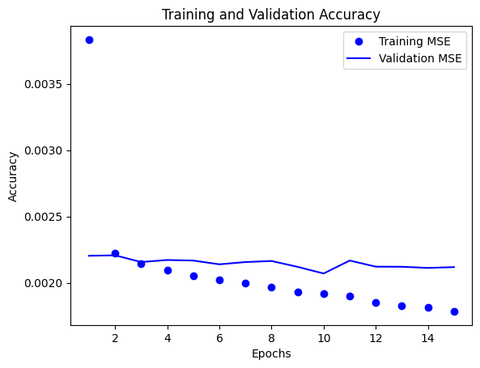

```python
model_5.save_weights('model_5.weights.h5')
print_history(history_5)
```

## Inspecting the model

- While not perfect, the model clearly improved.
- The model was able to color forests with green, and brick buildings in red.
- Transfer learning clearly enabled the model to identify more features and learn more color patterns.

```python
model_5.load_weights('model_5.weights.h5')
```

```
1/1 ━━━━━━━━━━━━━━━━━━━━ 1s 552ms/step
```

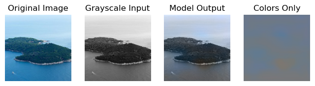

```
1/1 ━━━━━━━━━━━━━━━━━━━━ 0s 161ms/step
```

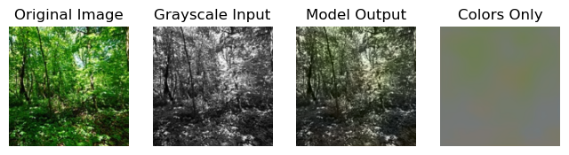

```
1/1 ━━━━━━━━━━━━━━━━━━━━ 0s 171ms/step
```

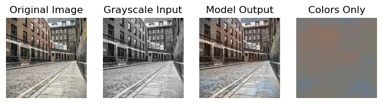

```
1/1 ━━━━━━━━━━━━━━━━━━━━ 0s 155ms/step
```

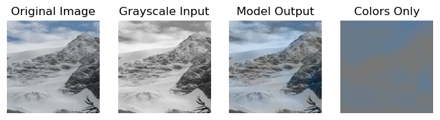

```python
print_prediction(model_5, 'landscape_images/test/landscape/1504.jpg')
print_prediction(model_5, 'landscape_images/test/landscape/1940.jpg')
print_prediction(model_5, 'landscape_images/test/landscape/1503.jpg')
print_prediction(model_5, 'landscape_images/test/landscape/1624.jpg')
```